# MTH6139 Time Series

Coursework 1 – 220299385

Zaiba Adam

Semester 2 2025/26

# Section 1: Antarctica Data

## 1.1 🧐 What does the dataset involve?

Measure of the “extent” of ice coverage in the Southern Hemisphere, daily over a 3 year period. Extent measures the total regional area with at least 15% ice coverage, in 10^6 sq km. Data is collected using thermal imagine and other reliable tools.

## 1.2 💻 This project?

It is clear Sea_Ice_Extent models a time series in R. As a Time Series student, this is of great interest, as it allows me to apply learnt principles, extracting trends, seasonality and noise to review underlying data and how this contributes to real life forecasts, risk management and environmental studies. Using Meta’s Prophet, I will complete analysis on this dataset, creating a useful tool for visualisation and forecasting.

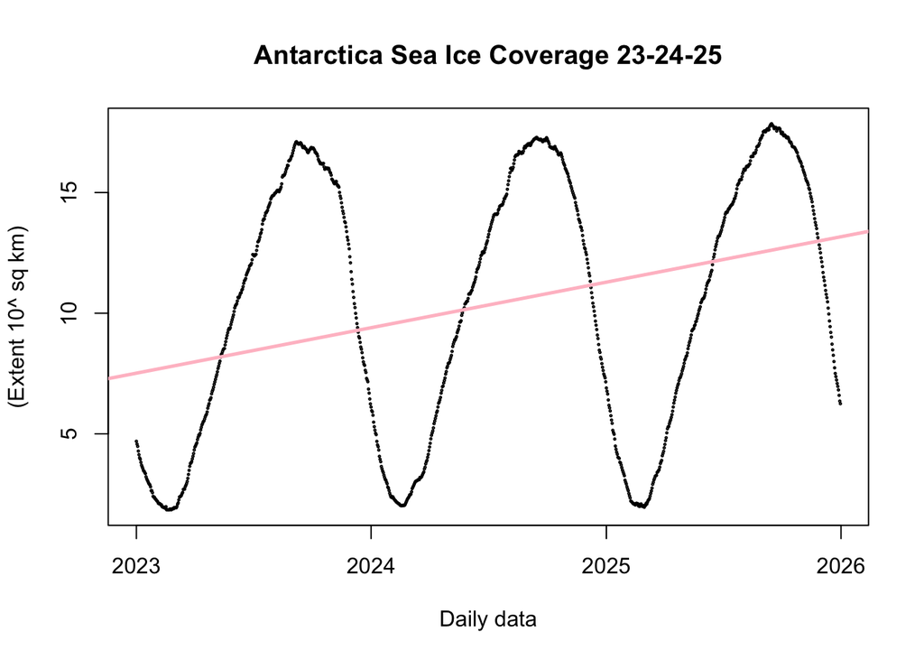

## 1.3 💭 Why is this dataset of interest? What can it be used for?

- global warming, health of the environment, impact on sea levels
- threats to wildlife / biodiversity🐜 🐧🐟🌱🦭
- research
- international ocean management and risk factor identification

# Section 2: Simplistic Analysis

We will conduct a decomposition on the time series, just to gauge a prior understanding of the data, before proceeding to Prophets [Section 3].

## 2.1 Simple Moving Average

From the pink linear regression line above, the upward sloping is more indicative of the rising and falling peaks, rather than a trend across data. A non-parametric approach may be more appropriate.

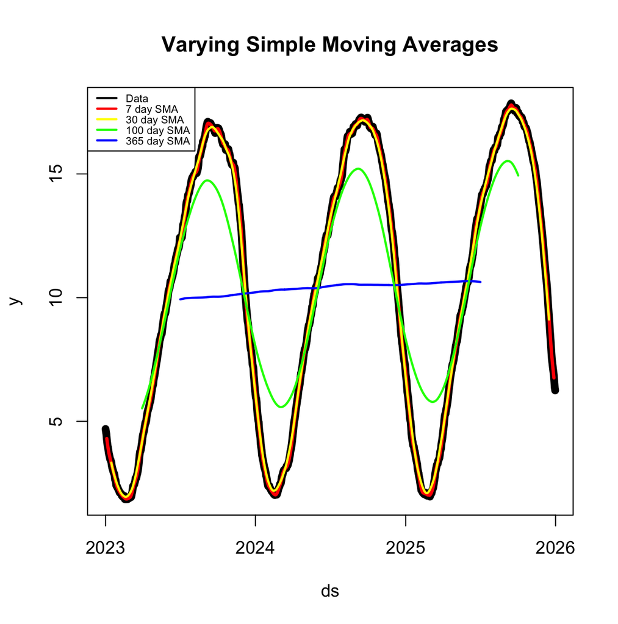

## 2.2 Additive vs Multiplicative?

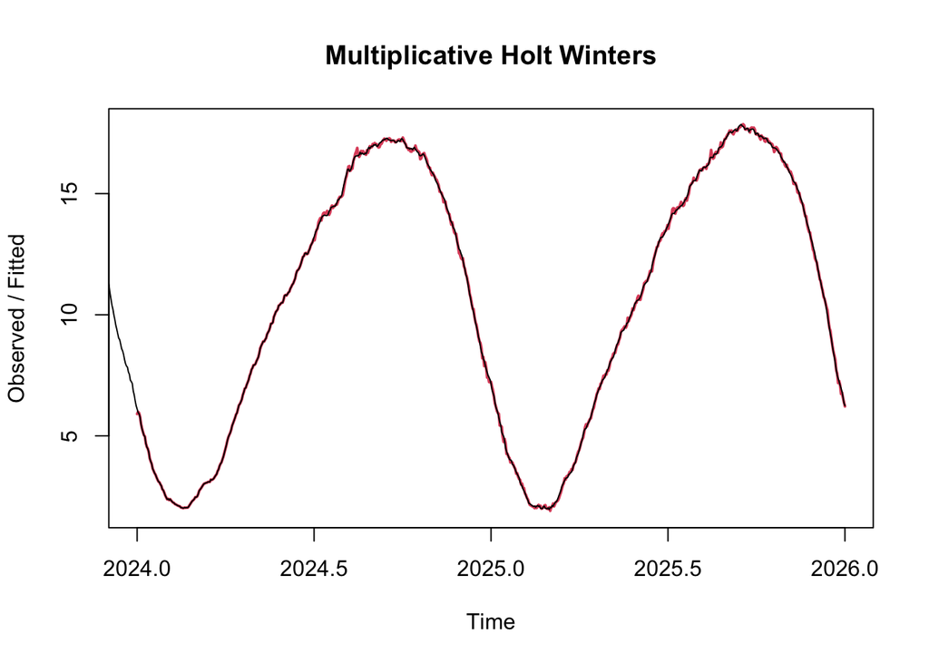

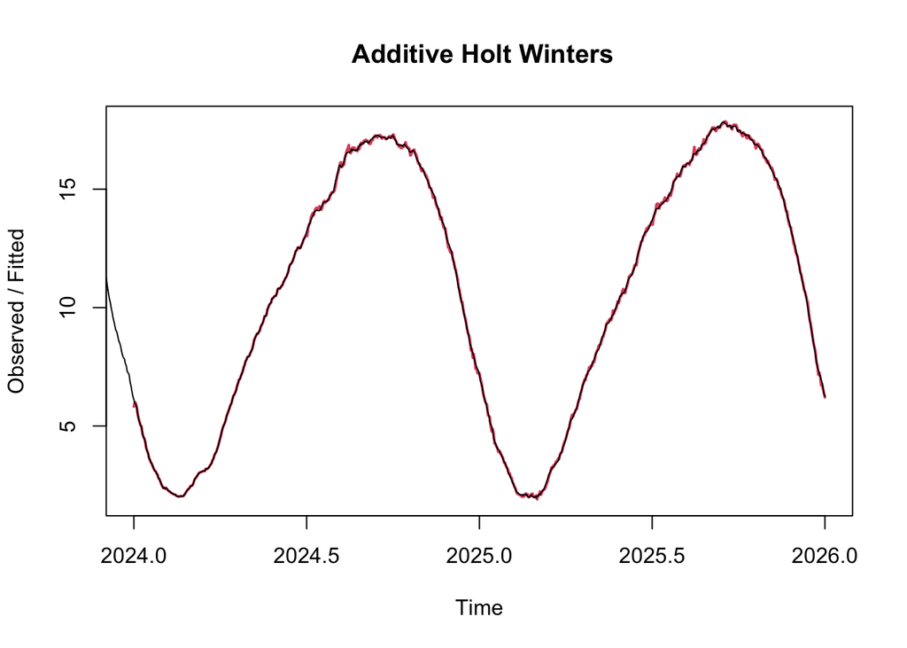

We can see both the additive and multiplicative HW look identical, this suggests the Seasonality is independent of trend, and expected for ice data.

> ➕ **Additive** The seasonality is constant regardless of trend

> ✖️ **Multiplicative** The seasonality changes in line with trend

## 2.3 Decomposition

Decomposing a TS gives us a brief outlook on what is occurring in our raw data.

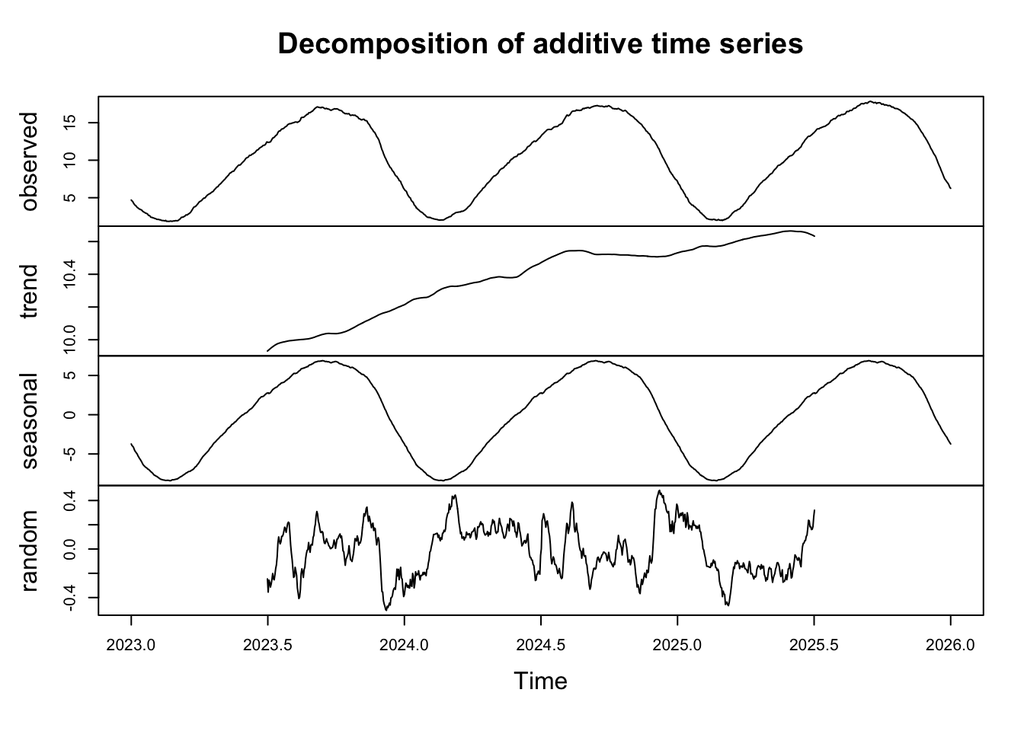

> 🔍 **Observed** This is our raw data, showing a consistent fluctutation in ice coverage.

> 📈 **Trend** Our trend line shows a very minimally increasing trend, somewhat linear but also cannot make a definitive answer since our Data is known to be very seasonal.

> 🗓️ **Seasonal** The seasonality is very consistent with the observed data, seasonality dominates the series.

**What can we deduce?**

Our Sea Ice Extent is predominantly based on Seasonality, minimally impacted with trend and noise. Although this is expected, maybe using 3 years of data has been too minimal to detect significant changes as a result of global warming.

# Section 3: Using Prophets

Using Prophets to analyse the Sea_Ice data.

Prophets is an additional analysis method, based on additive time series, whereby trends and seasonality are detected.  
Prophets works well for data with high seasonality, like this one, and is resilient to incomplete/ outlying data points. This helps to ensure analysis is complete and thorough.

## 3.1 Trend

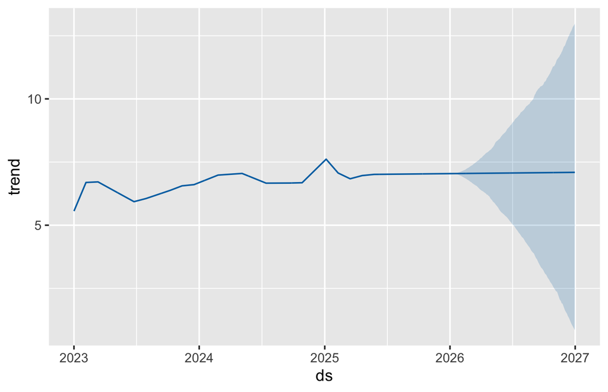

*Understanding the Trend*

- There is a slight increase from 2023 to 2026
- largest increases occured at the start of 2023 and 2025
- From 2025 ice coverage experienced a plateu
- Large shaded blue region for 2026 onwards shows a wider confidence interval for 2026 trend. This is consistent with only using 3 years of daily data.
- minimal increasing trend overall.

## 3.2 Seasonality

- It makes no sense to look for holiday seasonality in our series, ice does not stop melting on weekends, public holidays etc; should we have used financial data etc we would be detecting holiday seasonality.

## Daily

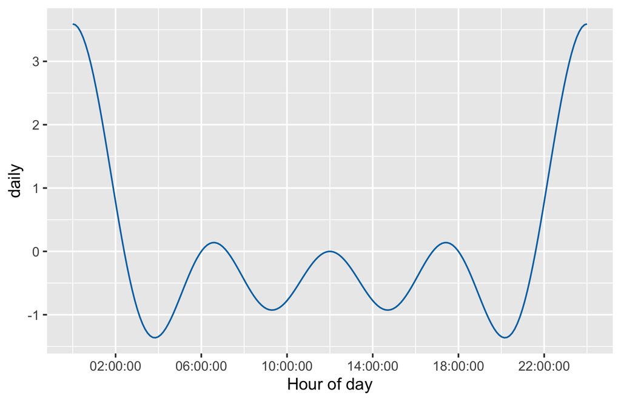

*Understanding Daily Seasonality*

## Weekly

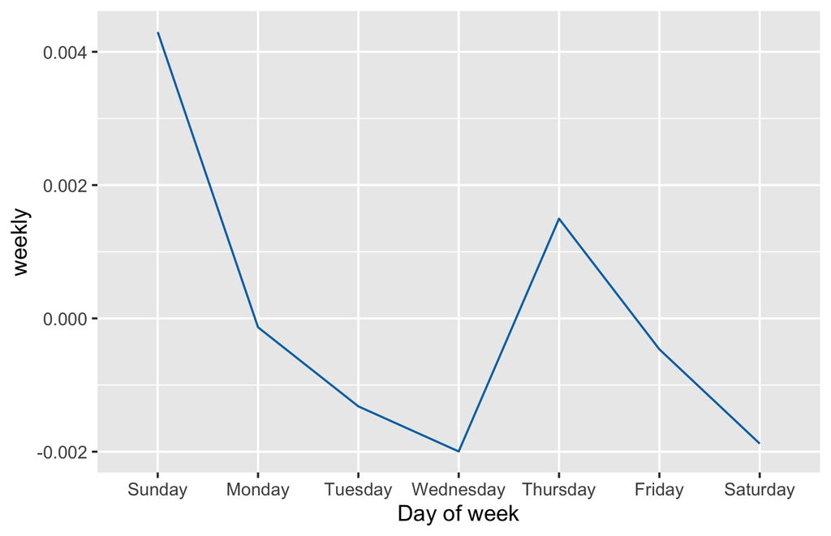

*Understanding Weekly Seasonality*

- Weekly data carries minimal significance to data analysis and application
- The lag/ dips seen throughout the week are usually due to reporting and processing data
- Weekly seasonality has only been generated as part of PROPHET -Any weekly meteorological events lasting over a week would present as outliers usually, not a weekly seasonality.

## Yearly

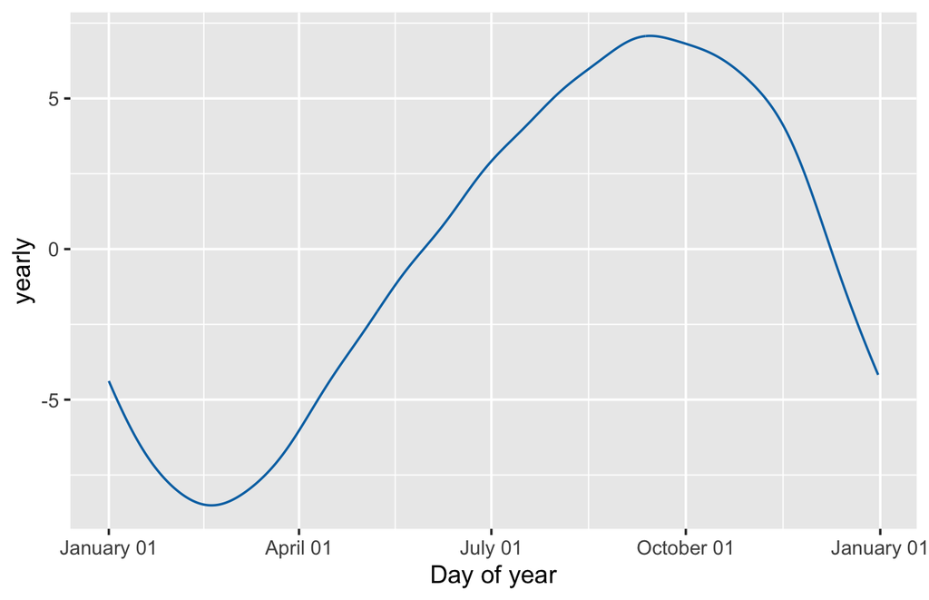

*Understanding Yearly Seasonality*

- Yearly seasonality presents as expected
- JAN to MAR: Summer in the Southern Hemisphere, low ice extent
- APR to JUN: Autumn, transition to increased ice coverage as solar exposure dwindles
- JUL-SEP: Winter, highest ice coverage for the year, coldest temperatures
- OCT to DEC: Spring, transition to Summer and falling ice extent.

## 3.3 Noise

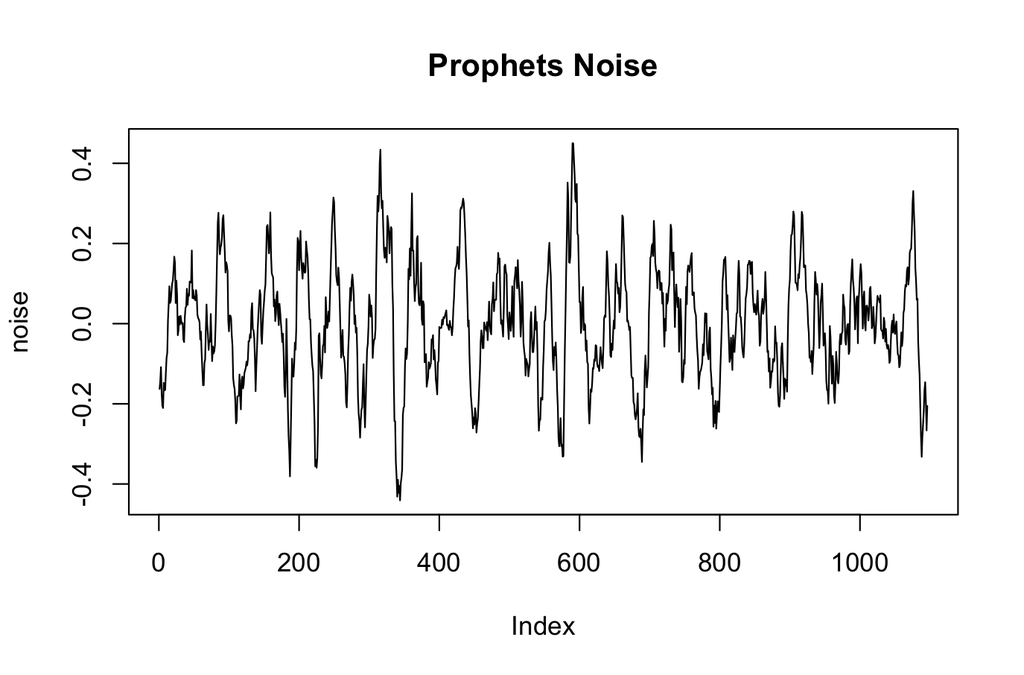

*Understanding Noise*

- This is a “good” noise plot, anchored around a zero mean with no clear pattern
- Demonstrates that Prophets has captured all the trend and seasonality of the data
- High fluctuations can be described as weather phenomenons experienced in the Southern Hemisphere, periods of strong winds, ocean currents etc

## 3.4 Predictions and Forecasting

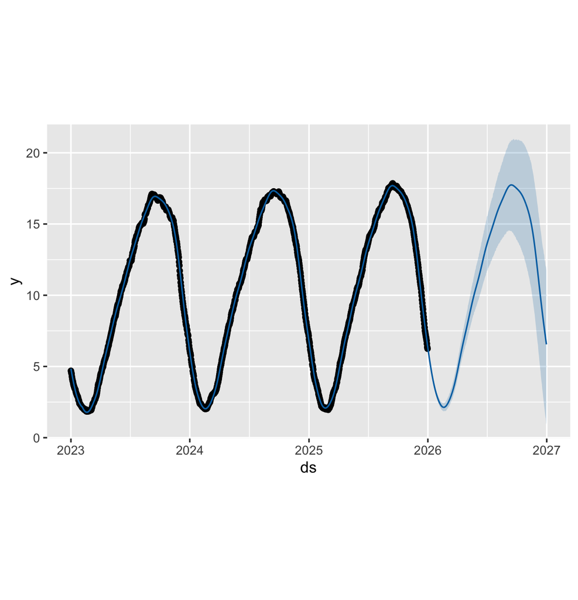

**Understanding this plot**

- Black line represents the raw data, taken from source
- Blue line overfit demonstrates Prophet forecasting based on Seasonality extracted
- The two lines are almost identical, suggesting the data is consistent over 3 years, and allowing Prophet to absorb.

**Take a closer look:**

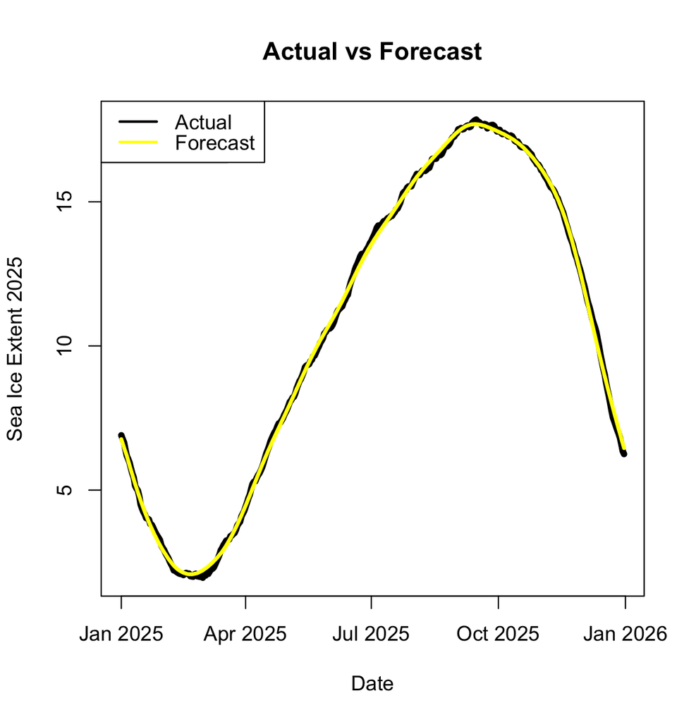

This simply shows how well Prophets forecasting works in alignment with raw data, with minimal deviations, same overall movement and shape.

> ⚠️ **CAUTION** Only using 3 years of data, Prophet may have learnt the predictability and overfit the model, disregarding variability and the dynamics of natural occurences.

# Section 4: Conclusions and Comparisons

In this final section, we will compare if our Simple Analysis on the raw Dataframe aligns with that of Prophets.

## 4.1 Seasonality

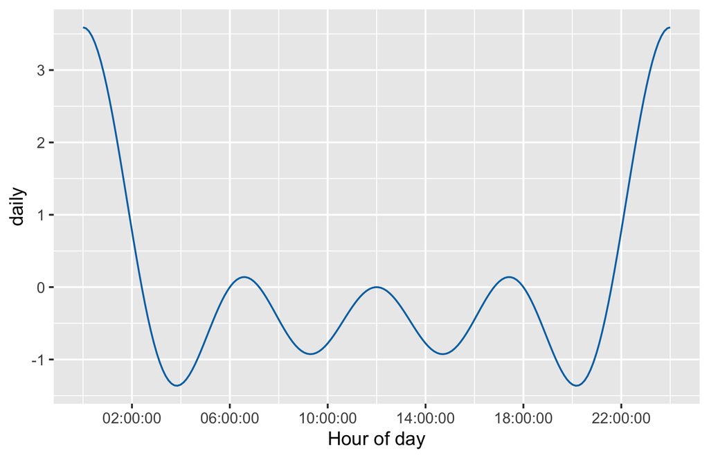

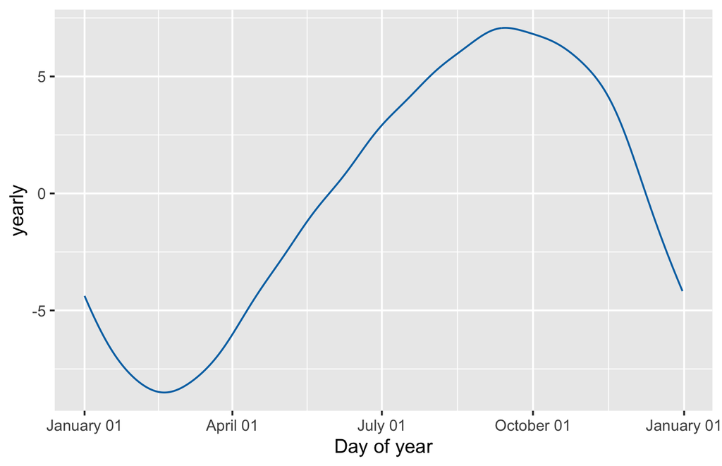

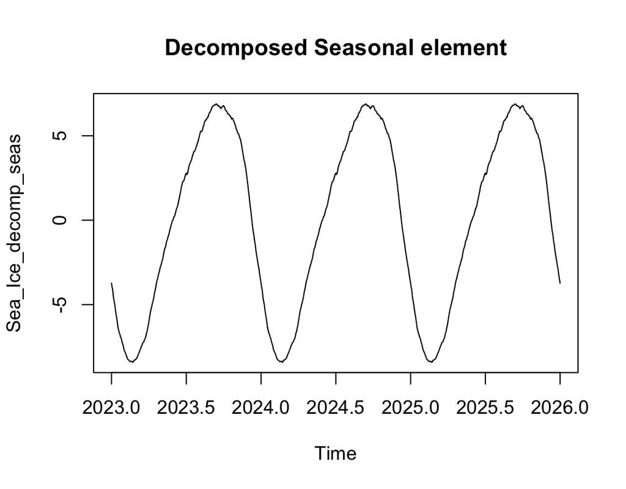

By comparing daily and annual seasonality, it can be justified that the Decomposition captures the overall trend well, however Prophets is much more detailed and can be extracted on varying time scales to provide more information.

## 4.2 Noise

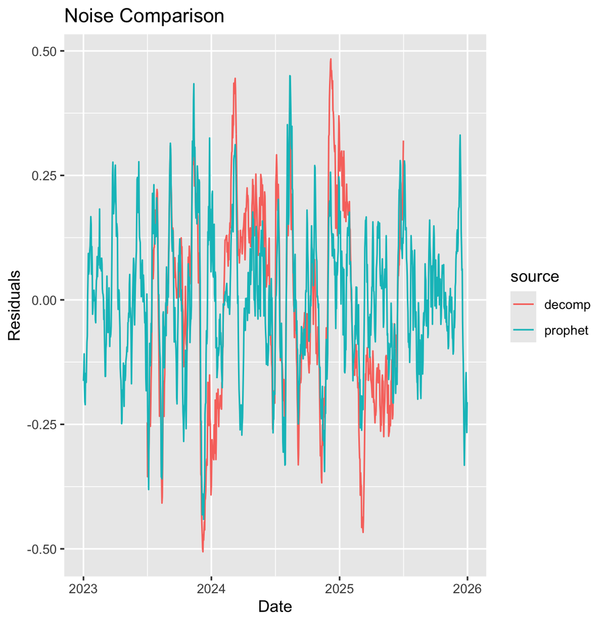

- decomp represents the random generated as part of decomposition of orignal time series
- prophet represents the noise gauged by prophet

Both show a consistent shape, pattern and movement around 0, highlighting we have extracted the minimal noise structure well.

## 4.3 Conclusion

Overall, Prophets has worked as expected in accordance with more Simple Analysis. Prophets is a concise, well informed library allowing for prediction, forecasting as well as extracting important components of raw data.

We can deduce that seasonality controls the Sea Ice Extent coverage in the Southern Hemisphere, a more “zoomed out” approach over a larger time period, ie 100 years, may demonstrate an alternative idea; as global warming patterns etc impact contributes.

# 👩🏽‍💻 References and Notes

Source Data: https://nsidc.org/data/seaice_index/data-and-image-archive

Meta Prophet Guide: https://facebook.github.io/prophet/docs/quick_start.html#r-api

Prophets Facebook page: https://facebook.github.io/prophet/

R Markdown Guide: https://yihui.org/rmarkdown-cookbook/figure-size

Remarks:

1.0 Note the dataset has been reduced to 2023/24/25 complete data. Daily data can be intensive to process and analyse, three years of whole data tends to provide sufficient insight.

1.1 Throughout analysis of my plots and Prophets, I do not think 3 years of data has been enough to detect the overall changes to Sea Ice Coverage in the Southern Hemisphere; increasing the data range may be more informative although not possible for R to handle!

2.0 Many additional packages and libraries have been called throughout this project; prophet, filter,readxl and are necessary for the underlying R code to work.